# Rozwiązania do zadań z lab 10

Porównywanie modeli i strojenie na siatkach regularnych

Author

Dariusz Majerek

Published

May 4, 2026

```r
library(tidymodels)
library(modeldata)
```

## Zadanie 1. Porównanie wariantów workflowu

Przygotowujemy ograniczony zbiór danych i obiekt resamplingu.

```r
set.seed(2026)

biomass_small <- biomass %>%
  select(HHV, carbon, hydrogen, oxygen, nitrogen, sulfur) %>%
  slice_sample(n = 220)

set.seed(2026)
biomass_folds <- vfold_cv(biomass_small, v = 5, strata = HHV)
```

Definiujemy trzy warianty preprocessingu. W pierwszym wariancie preprocessing jest zwykłą formułą, w kolejnych dwóch używamy receptur.

```r
raw_formula <- HHV ~ carbon + hydrogen + oxygen + nitrogen + sulfur

norm_rec <- recipe(raw_formula, data = biomass_small) %>%
  step_normalize(all_predictors())

pca_rec <- recipe(raw_formula, data = biomass_small) %>%
  step_normalize(all_predictors()) %>%
  step_pca(all_predictors(), num_comp = 3)

lm_spec <- linear_reg() %>%
  set_engine("lm")
```

Zestaw workflowów pozwala uruchomić te same resample dla wszystkich wariantów.

```r
biomass_set <- workflow_set(
  preproc = list(
    raw = raw_formula,
    norm = norm_rec,
    pca = pca_rec
  ),
  models = list(lm = lm_spec),
  cross = FALSE
)

biomass_set
```

```
# A workflow set/tibble: 3 × 4
  wflow_id info             option    result
  <chr>    <list>           <list>    <list>
1 raw_lm   <tibble [1 × 4]> <opts[0]> <list [0]>
2 norm_lm  <tibble [1 × 4]> <opts[0]> <list [0]>
3 pca_lm   <tibble [1 × 4]> <opts[0]> <list [0]>
```

Uruchamiamy ocenę workflowów.

```r
set.seed(2026)

biomass_res <- workflow_map(
  biomass_set,
  "fit_resamples",
  seed = 2026,
  resamples = biomass_folds,
  metrics = metric_set(rmse, rsq),
  control = control_resamples(save_pred = TRUE, save_workflow = TRUE),
  verbose = FALSE
)
```

Średnie metryk pokazują różnice między wariantami preprocessingu.

```r
collect_metrics(biomass_res)
```

```
# A tibble: 6 × 9
  wflow_id .config         preproc model  .metric .estimator  mean     n std_err
  <chr>    <chr>           <chr>   <chr>  <chr>   <chr>      <dbl> <int>   <dbl>
1 raw_lm   pre0_mod0_post0 formula linea… rmse    standard   1.89      5  0.427
2 raw_lm   pre0_mod0_post0 formula linea… rsq     standard   0.790     5  0.0731
3 norm_lm  pre0_mod0_post0 recipe  linea… rmse    standard   1.89      5  0.427
4 norm_lm  pre0_mod0_post0 recipe  linea… rsq     standard   0.790     5  0.0731
5 pca_lm   pre0_mod0_post0 recipe  linea… rmse    standard   2.54      5  0.298
6 pca_lm   pre0_mod0_post0 recipe  linea… rsq     standard   0.605     5  0.115
```

Do porównania sparowanego potrzebne są wyniki z pojedynczych foldów.

```r
fold_rmse <- biomass_res %>%
  collect_metrics(summarize = FALSE) %>%
  filter(.metric == "rmse") %>%
  select(wflow_id, id, .estimate)

fold_rmse
```

```
# A tibble: 15 × 3
   wflow_id id    .estimate
   <chr>    <chr>     <dbl>
 1 raw_lm   Fold1      3.50
 2 raw_lm   Fold2      1.93
 3 raw_lm   Fold3      1.12
 4 raw_lm   Fold4      1.30
 5 raw_lm   Fold5      1.57
 6 norm_lm  Fold1      3.50
 7 norm_lm  Fold2      1.93
 8 norm_lm  Fold3      1.12
 9 norm_lm  Fold4      1.30
10 norm_lm  Fold5      1.57
11 pca_lm   Fold1      3.22
12 pca_lm   Fold2      3.30
13 pca_lm   Fold3      1.91
14 pca_lm   Fold4      2.07
15 pca_lm   Fold5      2.20
```

Przekształcamy wyniki do szerokiej postaci, tak aby w jednym wierszu znajdowały się wyniki z tego samego foldu.

```r
fold_rmse_wide <- fold_rmse %>%
  pivot_wider(names_from = wflow_id, values_from = .estimate)

fold_rmse_wide
```

```
# A tibble: 5 × 4
  id    raw_lm norm_lm pca_lm
  <chr>  <dbl>   <dbl>  <dbl>
1 Fold1   3.50    3.50   3.22
2 Fold2   1.93    1.93   3.30
3 Fold3   1.12    1.12   1.91
4 Fold4   1.30    1.30   2.07
5 Fold5   1.57    1.57   2.20
```

Sparowany test t porównuje różnice `rmse` w tych samych foldach.

```r
t.test(fold_rmse_wide$pca_lm, fold_rmse_wide$raw_lm, paired = TRUE)
```

```
    Paired t-test

data:  fold_rmse_wide$pca_lm and fold_rmse_wide$raw_lm
t = 2.4553, df = 4, p-value = 0.07004
alternative hypothesis: true mean difference is not equal to 0
95 percent confidence interval:
 -0.08583978  1.39842565
sample estimates:
mean difference
      0.6562929
```

Wykres foldów ułatwia sprawdzenie, czy różnica jest systematyczna, czy wynika z pojedynczego podziału.

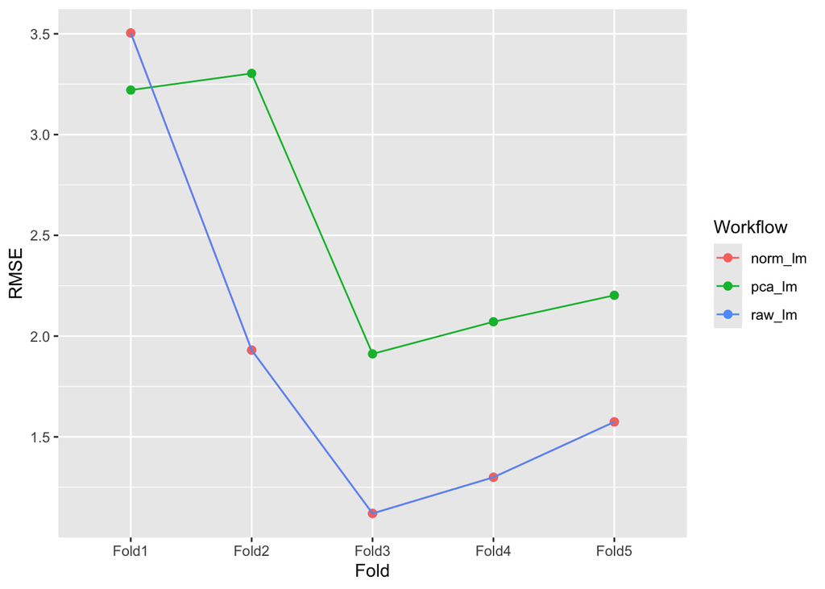

```r
fold_rmse %>%
  ggplot(aes(x = id, y = .estimate, color = wflow_id, group = wflow_id)) +
  geom_point(size = 2) +
  geom_line() +
  labs(
    x = "Fold",
    y = "RMSE",
    color = "Workflow"
  )
```

## Zadanie 2. Strojenie kNN na regularnej siatce

Przygotowujemy dane i podział trening-test.

```r
library(palmerpenguins)

set.seed(2026)

penguins_clean <- penguins %>%
  drop_na(
    species,
    bill_length_mm,
    bill_depth_mm,
    flipper_length_mm,
    body_mass_g,
    island,
    sex
  ) %>%
  mutate(species = factor(species))

penguins_split <- initial_split(penguins_clean, prop = 0.75, strata = species)
penguins_train <- training(penguins_split)
penguins_test <- testing(penguins_split)

set.seed(2026)
penguins_folds <- vfold_cv(penguins_train, v = 4, strata = species)
```

Receptura koduje predyktory nominalne i skaluje zmienne liczbowe.

```r
penguins_rec <- recipe(
  species ~ bill_length_mm + bill_depth_mm + flipper_length_mm +
    body_mass_g + island + sex,
  data = penguins_train
) %>%
  step_dummy(all_nominal_predictors()) %>%
  step_zv(all_predictors()) %>%
  step_normalize(all_numeric_predictors())
```

W modelu kNN oznaczamy trzy hiperparametry do strojenia.

```r
knn_spec <- nearest_neighbor(
  neighbors = tune(),
  weight_func = tune(),
  dist_power = tune()
) %>%
  set_engine("kknn") %>%
  set_mode("classification")

penguins_wf <- workflow() %>%
  add_recipe(penguins_rec) %>%
  add_model(knn_spec)
```

Wyodrębnienie parametrów pozwala sprawdzić ich typy i domyślne zakresy.

```r
penguins_params <- extract_parameter_set_dials(penguins_wf)
penguins_params
```

[output not shown]

Budujemy regularną siatkę. Liczba wierszy siatki jest iloczynem liczby poziomów dla kolejnych parametrów.

```r
penguins_grid <- grid_regular(
  neighbors(range = c(3L, 17L)),
  weight_func(values = c("rectangular", "triangular")),
  dist_power(range = c(1, 2)),
  levels = c(5, 2, 2)
)

penguins_grid
```

```
# A tibble: 20 × 3
   neighbors weight_func dist_power
       <int> <chr>            <dbl>
 1         3 rectangular          1
 2         6 rectangular          1
 3        10 rectangular          1
 4        13 rectangular          1
 5        17 rectangular          1
 6         3 triangular           1
 7         6 triangular           1
 8        10 triangular           1
 9        13 triangular           1
10        17 triangular           1
11         3 rectangular          2
12         6 rectangular          2
13        10 rectangular          2
14        13 rectangular          2
15        17 rectangular          2
16         3 triangular           2
17         6 triangular           2
18        10 triangular           2
19        13 triangular           2
20        17 triangular           2
```

Uruchamiamy strojenie.

```r
set.seed(2026)

penguins_tune <- tune_grid(
  penguins_wf,
  resamples = penguins_folds,
  grid = penguins_grid,
  metrics = metric_set(accuracy, roc_auc),
  control = control_grid(save_pred = TRUE)
)
```

Najlepsze konfiguracje według `accuracy`:

```r
show_best(penguins_tune, metric = "accuracy", n = 8)
```

```
# A tibble: 8 × 9
  neighbors weight_func dist_power .metric  .estimator  mean     n std_err
      <int> <chr>            <dbl> <chr>    <chr>      <dbl> <int>   <dbl>
1         3 rectangular          1 accuracy multiclass 0.996     4 0.00403
2         6 rectangular          1 accuracy multiclass 0.996     4 0.00403
3        10 rectangular          1 accuracy multiclass 0.996     4 0.00403
4        10 rectangular          2 accuracy multiclass 0.996     4 0.00403
5        10 triangular           1 accuracy multiclass 0.996     4 0.00403
6        13 rectangular          1 accuracy multiclass 0.996     4 0.00403
7        13 rectangular          2 accuracy multiclass 0.996     4 0.00403
8        13 triangular           1 accuracy multiclass 0.996     4 0.00403
# ℹ 1 more variable: .config <chr>
```

Wybieramy najlepszą konfigurację i finalizujemy workflow.

```r
best_penguins <- select_best(penguins_tune, metric = "accuracy")
best_penguins
```

```
# A tibble: 1 × 4
  neighbors weight_func dist_power .config
      <int> <chr>            <dbl> <chr>
1         3 rectangular          1 pre0_mod01_post0
```

```r
final_penguins_wf <- finalize_workflow(penguins_wf, best_penguins)
final_penguins_fit <- fit(final_penguins_wf, data = penguins_train)
```

Ocena na zbiorze testowym:

```r
penguins_test_pred <- penguins_test %>%
  select(species) %>%
  bind_cols(predict(final_penguins_fit, new_data = penguins_test)) %>%
  bind_cols(predict(final_penguins_fit, new_data = penguins_test, type = "prob"))

accuracy(penguins_test_pred, truth = species, estimate = .pred_class)
```

```
# A tibble: 1 × 3
  .metric  .estimator .estimate
  <chr>    <chr>          <dbl>
1 accuracy multiclass         1
```

```r
roc_auc(
  penguins_test_pred,
  truth = species,
  .pred_Adelie,
  .pred_Chinstrap,
  .pred_Gentoo
)
```

```
# A tibble: 1 × 3
  .metric .estimator .estimate
  <chr>   <chr>          <dbl>
1 roc_auc hand_till          1
```

## Zadanie 3. Ta sama siatka, różne metryki wyboru

Przygotowujemy ograniczoną próbę i podział trening-test.

```r
set.seed(2026)

two_class_small <- two_class_dat %>%
  slice_sample(n = 500)

two_class_split <- initial_split(two_class_small, prop = 0.75, strata = Class)
two_class_train <- training(two_class_split)
two_class_test <- testing(two_class_split)

set.seed(2026)
two_class_folds <- vfold_cv(two_class_train, v = 5, strata = Class)
```

Definiujemy workflow drzewa klasyfikacyjnego.

```r
tree_rec <- recipe(Class ~ ., data = two_class_train) %>%
  step_zv(all_predictors())

tree_spec <- decision_tree(
  cost_complexity = tune(),
  tree_depth = tune(),
  min_n = tune()
) %>%
  set_engine("rpart") %>%
  set_mode("classification")

tree_wf <- workflow() %>%
  add_recipe(tree_rec) %>%
  add_model(tree_spec)
```

Regularna siatka obejmuje trzy hiperparametry drzewa.

```r
tree_grid <- grid_regular(
  cost_complexity(range = c(-4, -1)),
  tree_depth(range = c(2L, 8L)),
  min_n(range = c(5L, 25L)),
  levels = c(4, 4, 3)
)

tree_grid
```

```
# A tibble: 48 × 3
   cost_complexity tree_depth min_n
             <dbl>      <int> <int>
 1          0.0001          2     5
 2          0.001           2     5
 3          0.01            2     5
 4          0.1             2     5
 5          0.0001          4     5
 6          0.001           4     5
 7          0.01            4     5
 8          0.1             4     5
 9          0.0001          6     5
10          0.001           6     5
# ℹ 38 more rows
```

Stroimy model na tej samej siatce dla kilku metryk.

```r
set.seed(2026)

tree_tune <- tune_grid(
  tree_wf,
  resamples = two_class_folds,
  grid = tree_grid,
  metrics = metric_set(roc_auc, accuracy, sens, specificity),
  control = control_grid(save_pred = TRUE)
)
```

Najlepsze konfiguracje według `roc_auc`:

```r
show_best(tree_tune, metric = "roc_auc", n = 5)
```

```
# A tibble: 5 × 9
  cost_complexity tree_depth min_n .metric .estimator  mean     n std_err
            <dbl>      <int> <int> <chr>   <chr>      <dbl> <int>   <dbl>
1          0.0001          6    25 roc_auc binary     0.877     5  0.0178
2          0.0001          8    25 roc_auc binary     0.877     5  0.0178
3          0.001           6    25 roc_auc binary     0.877     5  0.0178
4          0.001           8    25 roc_auc binary     0.877     5  0.0178
5          0.0001          4    25 roc_auc binary     0.877     5  0.0179
# ℹ 1 more variable: .config <chr>
```

Najlepsze konfiguracje według `accuracy`:

```r
show_best(tree_tune, metric = "accuracy", n = 5)
```

```
# A tibble: 5 × 9
  cost_complexity tree_depth min_n .metric  .estimator  mean     n std_err
            <dbl>      <int> <int> <chr>    <chr>      <dbl> <int>   <dbl>
1            0.01          6    15 accuracy binary     0.816     5 0.00982
2            0.01          8    15 accuracy binary     0.816     5 0.00982
3            0.01          6     5 accuracy binary     0.813     5 0.0108
4            0.01          8     5 accuracy binary     0.813     5 0.0108
5            0.01          4    15 accuracy binary     0.813     5 0.00962
# ℹ 1 more variable: .config <chr>
```

Wybieramy dwa zestawy parametrów.

```r
best_tree_auc <- select_best(tree_tune, metric = "roc_auc")
best_tree_acc <- select_best(tree_tune, metric = "accuracy")

best_tree_auc
```

```
# A tibble: 1 × 4
  cost_complexity tree_depth min_n .config
            <dbl>      <int> <int> <chr>
1          0.0001          6    25 pre0_mod09_post0
```

```r
best_tree_acc
```

```
# A tibble: 1 × 4
  cost_complexity tree_depth min_n .config
            <dbl>      <int> <int> <chr>
1            0.01          6    15 pre0_mod32_post0
```

Porównanie wskazuje, czy różne metryki prowadzą do tego samego modelu.

```r
bind_rows(
  best_tree_auc %>% mutate(selection_metric = "roc_auc"),
  best_tree_acc %>% mutate(selection_metric = "accuracy")
) %>%
  select(selection_metric, everything())
```

```
# A tibble: 2 × 5
  selection_metric cost_complexity tree_depth min_n .config
  <chr>                      <dbl>      <int> <int> <chr>
1 roc_auc                   0.0001          6    25 pre0_mod09_post0
2 accuracy                  0.01            6    15 pre0_mod32_post0
```

Dopasowujemy modele końcowe.

```r
final_tree_auc <- finalize_workflow(tree_wf, best_tree_auc) %>%
  fit(two_class_train)

final_tree_acc <- finalize_workflow(tree_wf, best_tree_acc) %>%
  fit(two_class_train)
```

Funkcja pomocnicza liczy metryki na zbiorze testowym.

```r
evaluate_tree <- function(model_fit, data, model_name) {
  pred <- data %>%
    select(Class) %>%
    bind_cols(predict(model_fit, new_data = data)) %>%
    bind_cols(predict(model_fit, new_data = data, type = "prob"))

  bind_rows(
    roc_auc(pred, truth = Class, .pred_Class1),
    accuracy(pred, truth = Class, estimate = .pred_class)
  ) %>%
    mutate(model = model_name)
}

bind_rows(
  evaluate_tree(final_tree_auc, two_class_test, "wybór według roc_auc"),
  evaluate_tree(final_tree_acc, two_class_test, "wybór według accuracy")
) %>%
  select(model, .metric, .estimate)
```

```
# A tibble: 4 × 3
  model                 .metric  .estimate
  <chr>                 <chr>        <dbl>
1 wybór według roc_auc  roc_auc      0.875
2 wybór według roc_auc  accuracy     0.816
3 wybór według accuracy roc_auc      0.843
4 wybór według accuracy accuracy     0.816
```

## Zadanie 4. Strojenie parametrów modelu i receptury

Przygotowujemy ograniczoną próbę danych.

```r
set.seed(2026)

sacramento_small <- Sacramento %>%
  filter(sqft > 0, beds > 0, baths > 0) %>%
  slice_sample(n = 420)

sacramento_split <- initial_split(sacramento_small, prop = 0.8, strata = price)
sacramento_train <- training(sacramento_split)
sacramento_test <- testing(sacramento_split)

set.seed(2026)
sacramento_folds <- vfold_cv(sacramento_train, v = 4, strata = price)
```

W recepturze stroimy dwa progi grupowania rzadkich kategorii. Drugi próg otrzymuje własną nazwę, aby w siatce można było odróżnić go od progu dla `city`.

```r
sacramento_rec <- recipe(
  price ~ city + zip + beds + baths + sqft + type + latitude + longitude,
  data = sacramento_train
) %>%
  step_log(sqft, price, offset = 1) %>%
  step_other(city, threshold = tune()) %>%
  step_other(zip, threshold = tune("zip_threshold")) %>%
  step_dummy(all_nominal_predictors()) %>%
  step_zv(all_predictors()) %>%
  step_normalize(all_numeric_predictors())
```

Model `glmnet` ma dwa strojonie parametry: siłę kary i udział kary LASSO.

```r
glmnet_spec <- linear_reg(
  penalty = tune(),
  mixture = tune()
) %>%
  set_engine("glmnet")

sacramento_wf <- workflow() %>%
  add_recipe(sacramento_rec) %>%
  add_model(glmnet_spec)
```

Wyodrębniamy parametry i aktualizujemy zakresy.

```r
sacramento_params <- sacramento_wf %>%
  extract_parameter_set_dials() %>%
  update(
    threshold = threshold(c(0.01, 0.08)),
    zip_threshold = threshold(c(0.01, 0.08)),
    penalty = penalty(c(-4, -1))
  )

sacramento_params
```

[output not shown]

Regularna siatka łączy poziomy parametrów receptury i modelu.

```r
sacramento_grid <- sacramento_params %>%
  grid_regular(
    levels = c(
      threshold = 2,
      zip_threshold = 2,
      penalty = 4,
      mixture = 3
    )
  )

sacramento_grid
```

```
# A tibble: 48 × 4
   penalty mixture threshold zip_threshold
     <dbl>   <dbl>     <dbl>         <dbl>
 1  0.0001   0.05       0.01          0.01
 2  0.001    0.05       0.01          0.01
 3  0.01     0.05       0.01          0.01
 4  0.1      0.05       0.01          0.01
 5  0.0001   0.525      0.01          0.01
 6  0.001    0.525      0.01          0.01
 7  0.01     0.525      0.01          0.01
 8  0.1      0.525      0.01          0.01
 9  0.0001   1          0.01          0.01
10  0.001    1          0.01          0.01
# ℹ 38 more rows
```

Uruchamiamy strojenie.

```r
set.seed(2026)

sacramento_tune <- tune_grid(
  sacramento_wf,
  resamples = sacramento_folds,
  grid = sacramento_grid,
  metrics = metric_set(rmse, rsq),
  control = control_grid(save_pred = TRUE)
)
```

Najlepsze konfiguracje według `rmse`:

```r
show_best(sacramento_tune, metric = "rmse", n = 8)
```

```
# A tibble: 8 × 10
  penalty mixture threshold zip_threshold .metric .estimator  mean     n std_err
    <dbl>   <dbl>     <dbl>         <dbl> <chr>   <chr>      <dbl> <int>   <dbl>
1  0.01     0.525      0.01          0.08 rmse    standard   0.330     4  0.0128
2  0.01     1          0.01          0.08 rmse    standard   0.331     4  0.0133
3  0.01     0.05       0.01          0.08 rmse    standard   0.333     4  0.0133
4  0.001    1          0.01          0.08 rmse    standard   0.333     4  0.0124
5  0.001    0.525      0.01          0.08 rmse    standard   0.334     4  0.0126
6  0.001    0.05       0.01          0.08 rmse    standard   0.335     4  0.0131
7  0.0001   0.05       0.01          0.08 rmse    standard   0.335     4  0.0132
8  0.0001   0.525      0.01          0.08 rmse    standard   0.335     4  0.0131
# ℹ 1 more variable: .config <chr>
```

Wybieramy najlepszy zestaw parametrów i finalizujemy workflow.

```r
best_sacramento <- select_best(sacramento_tune, metric = "rmse")
best_sacramento
```

```
# A tibble: 1 × 5
  penalty mixture threshold zip_threshold .config
    <dbl>   <dbl>     <dbl>         <dbl> <chr>
1    0.01   0.525      0.01          0.08 pre2_mod08_post0
```

```r
final_sacramento_wf <- finalize_workflow(sacramento_wf, best_sacramento)
```

Ocena końcowa na zbiorze testowym:

```r
set.seed(2026)

sacramento_last <- last_fit(
  final_sacramento_wf,
  split = sacramento_split,
  metrics = metric_set(rmse, rsq)
)

collect_metrics(sacramento_last)
```

```
# A tibble: 2 × 4
  .metric .estimator .estimate .config
  <chr>   <chr>          <dbl> <chr>
1 rmse    standard       0.362 pre0_mod0_post0
2 rsq     standard       0.637 pre0_mod0_post0
```